# p8105_hw1_ks3663

Kee-Young Shin

September 13, 2018

## Problem 1

**Creating Problem 1 Data Frame**

```r
set.seed(1)

random_sample = runif(10, 0, 5)
vec_logic = random_sample > 2
vec_char = as.character(vec_logic) # created character vector by coercing vec_logic
vec_factor = as.factor(vec_logic)  # created factor vector by coercing vec_logic

first_df = data.frame(
  random_sample, vec_logic, vec_char, vec_factor, stringsAsFactors = FALSE)

mean(first_df$random_sample) # taking the mean of each variable in the data frame
```

```
## [1] 2.757569
```

```r
mean(first_df$vec_logic)
```

```
## [1] 0.6
```

```r
mean(first_df$vec_char)
```

```
## [1] NA
```

```r
mean(first_df$vec_factor)
```

```
## [1] NA
```

*What happens?*  
The means of the random sample vector and logical vector are able to be calculated since there are real numbers in the vectors (True and False are assigned values 1 and 0). The mean of the logical vector essentially shows the proportion of TRUEs in the vector. On the other hand, the means of the character vector and factor vector cannot be calculated because there are no numbers assigned to those vectors.

**Converting Variables From One Type to Another**

```r
as.numeric(first_df$vec_logic) #converts to values of 1 and 0
as.numeric(first_df$vec_char) #converts to a vector full of NA since there is no number
as.numeric(first_df$vec_factor) #saying first element is level 2
```

[output not shown]

*What happens?*  
The logic vector is able to be turned into a numeric vector since True and False can be converted to 1 and 0, respectively, in R. The factor vector is able to be converted into a numeric vector related to the levels of the values in it. The character vector is turned into a vector full of NA’s since a character cannot be coerced into a numeric.

**Converting a Variable Twice**

```r
as.numeric(as.factor(first_df$vec_char)) # converting from charcter to factor to numeric
```

```
##  [1] 1 1 2 2 1 2 2 2 2 1
```

```r
as.numeric(as.character(first_df$vec_factor)) # from factor to character to numeric
```

```
##  [1] NA NA NA NA NA NA NA NA NA NA
```

*What happens?*  
The character vector is turned into a factor vector with two levels “FALSE” and “TRUE”. The factor is then turned into a numeric vector according to the levels- 1 and 2- of the values in the factor vector. The reverse, however, does not work. Though the factor vector can be turned into a character vector, the character vector cannot be converted to a numeric vector since it is full of characters “TRUE” and “FALSE”.

## Problem 2

**Creating Problem 2 Data Frame**

```r
x = rnorm(1000)
y = rnorm(1000)
pr2_log = (x + y) > 0
pr2_numeric = as.numeric(pr2_log)  # coerced logical vector into numeric
pr2_factor = as.factor(pr2_log)  # coerced logical vector into factor

second_df = data.frame(x, y, pr2_log, pr2_numeric, pr2_factor)
```

*Description of data frame*  
size of data set: 1000 rows and 5 columns

mean of x = -0.0106382

median of x = -0.031318

proportion of cases logical vector is true = 0.49

**Creating Scatter Plots**

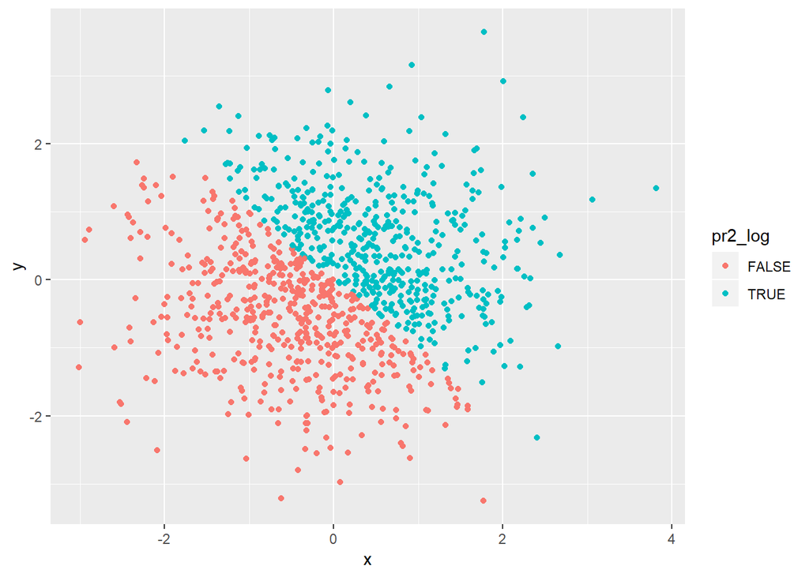

```r
library(ggplot2)

plot_log = ggplot(second_df, aes(x = x, y = y, color = pr2_log)) + geom_point()

plot_log
```

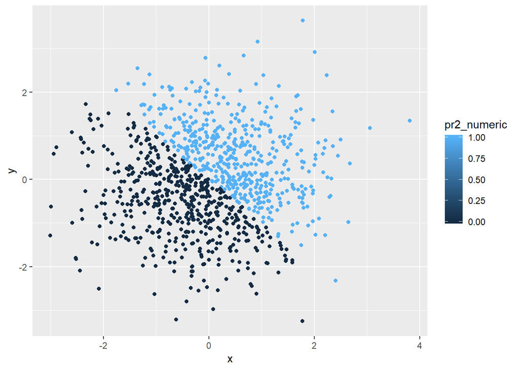

```r
plot_num = ggplot(second_df, aes(x = x, y = y, color = pr2_numeric)) + geom_point()

plot_num     #since it is numeric vector it is continuous
```

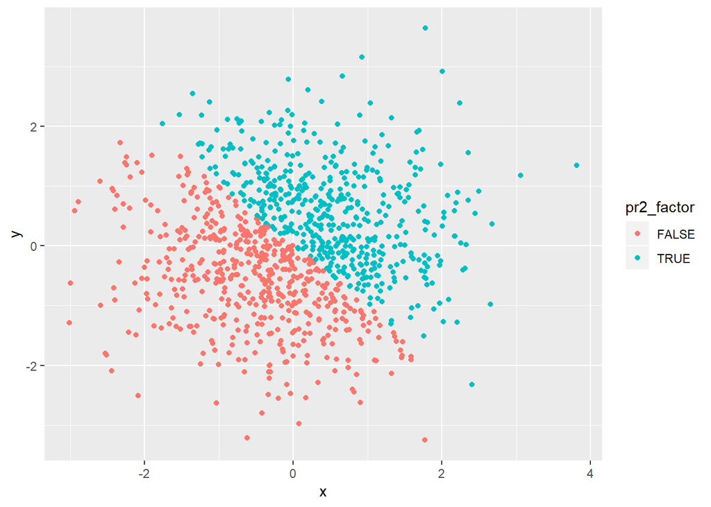

```r
plot_fac = ggplot(second_df, aes(x = x, y = y, color = pr2_factor)) + geom_point()

plot_fac
```

```r
ggsave("plot1.jpg", plot_log)
```